# Projet CNRS Partie 3

TO Vincent, JUDY PAUL Lathan, BHOWON Vivek, OUFFOUE Nanan, BAUDOUIN Alexis, KAMGA TALA Cyrille

15/04/2022

# INSTALLATION ET CHARGEMENT DES PACKAGES

```r
#install.packages("tidyverse")
#install.packages("xlsx")
#install.packages("UsingR")
library(tidyverse)
library(readxl)
library("xlsx")
library(UsingR)
library(ggplot2)
library(car)

setwd("h:/Desktop/ProjetCNRS")
data = read_excel("BDD_finale.xlsx")
```

# REMPLACEMENTS

```r
data1 = data
data1$Experience_min[data$Experience_min=='NP']<-0  #remplacement NP par valeur 0
data1$Experience_min[data$Experience_min=='1Exp']<-1  #remplacement 1Exp par valeur 1
data1$Experience_min[data$Experience_min=='Exp']<-3  #remplacement Exp par valeur 3
data1$Experience_max[data$Experience_max=='0']<-0
data1$Experience_max[data$Experience_max=='1']<-1
data1$Experience_max[data$Experience_max=='2']<-2
data1$Experience_max[data$Experience_max=='3']<-3
data1$Experience_max[data$Experience_max=='4']<-4
data1$Experience_max[data$Experience_max=='5']<-5
data1$Experience_max[data$Experience_max=='6']<-6
data1$Experience_max[data$Experience_max=='7']<-7
data1$Experience_max[data$Experience_max=='8']<-8

data1$Experience_min = as.numeric(data1$Experience_min)

data2=data1
data2$Size[data$Size=='De 1 à 50 employés']<-"Petites entreprises"
data2$Size[data$Size=='De 51 à 200 employés']<-"Entreprises moyennes"
data2$Size[data$Size=='Entre 201 et 500 employés']<-"Entreprises de Taille Intermédiaire"
data2$Size[data$Size=='De 501 à 1 000 employés']<-"Entreprises de Taille Intermédiaire"
data2$Size[data$Size=='De 1 001 à 5 000 employés']<-"Entreprises de Taille Intermédiaire"
data2$Size[data$Size=='De 5 001 à 10 000 employés']<-"Grandes entreprises"
data2$Size[data$Size=='Plus de 10 000 employés']<-"Grandes entreprises"
```

# STATISTIQUES DESCRIPTIVES

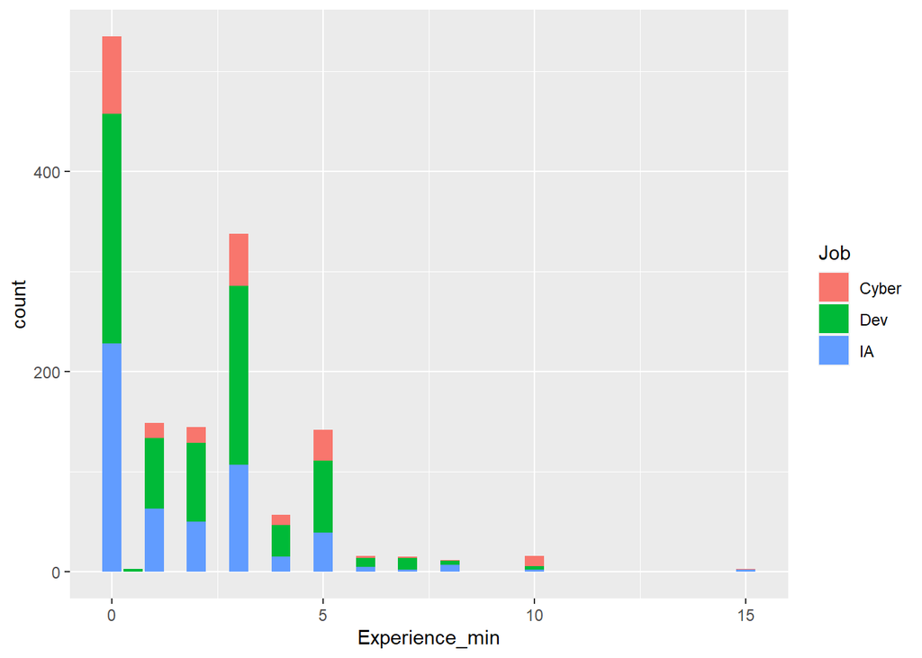

```r
ggplot(data2) + aes(x = Experience_min, fill = Job) + geom_bar()
```

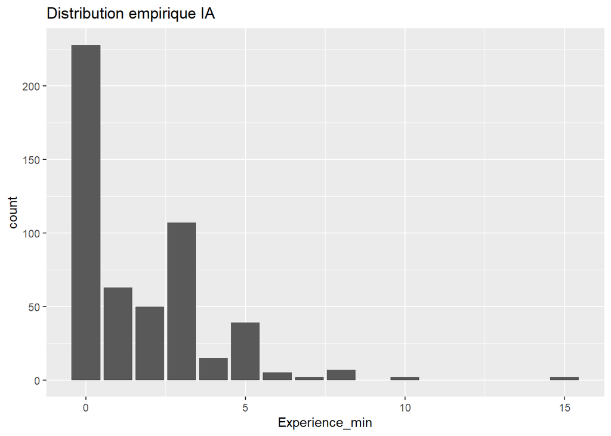

```r
dataIA = subset(data2, Job=='IA')
dataDev = subset(data2, Job=='Dev')
dataCyber = subset(data2, Job=='Cyber')

ggplot(dataIA) + aes(x = Experience_min) + geom_bar() + ggtitle("Distribution empirique IA")
```

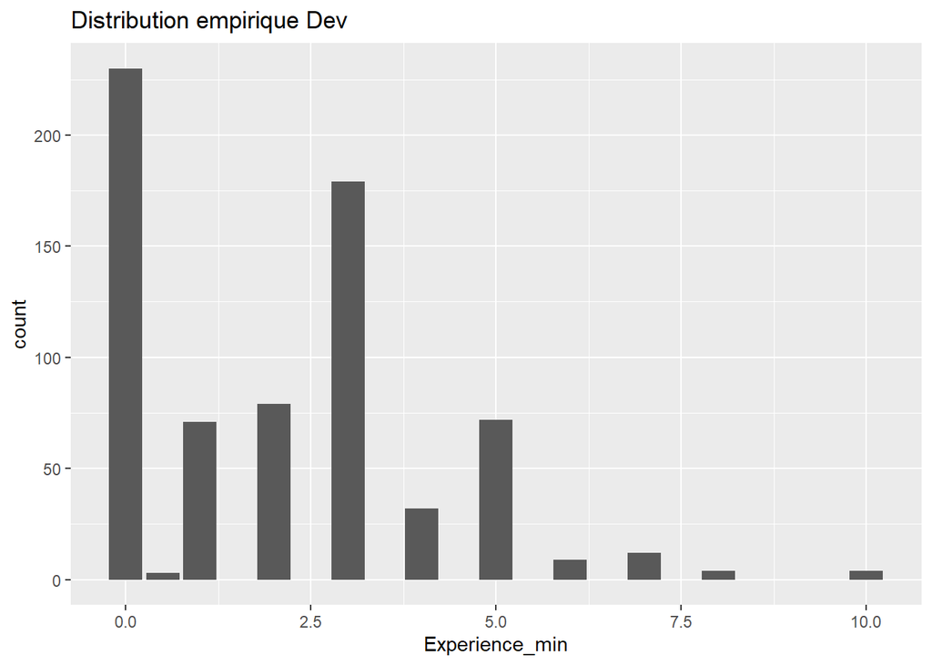

```r
ggplot(dataDev) + aes(x = Experience_min) + geom_bar() + ggtitle("Distribution empirique Dev")
```

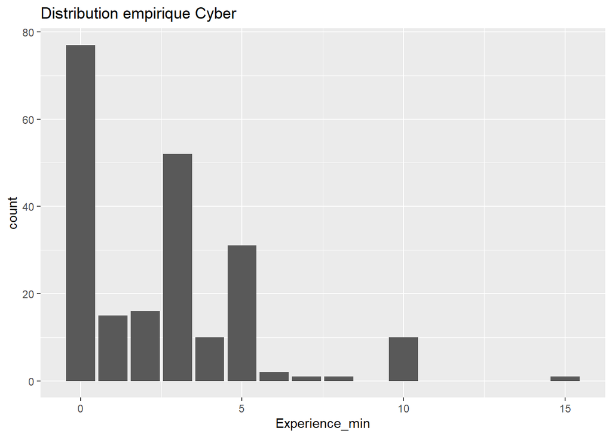

```r
ggplot(dataCyber) + aes(x = Experience_min) + geom_bar() + ggtitle("Distribution empirique Cyber")
```

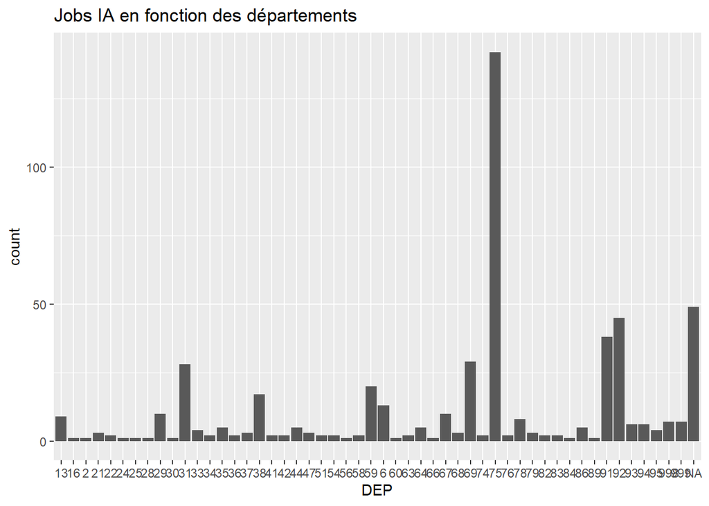

```r
ggplot(dataIA) + aes(x = DEP) + geom_bar() + ggtitle("Jobs IA en fonction des départements")
```

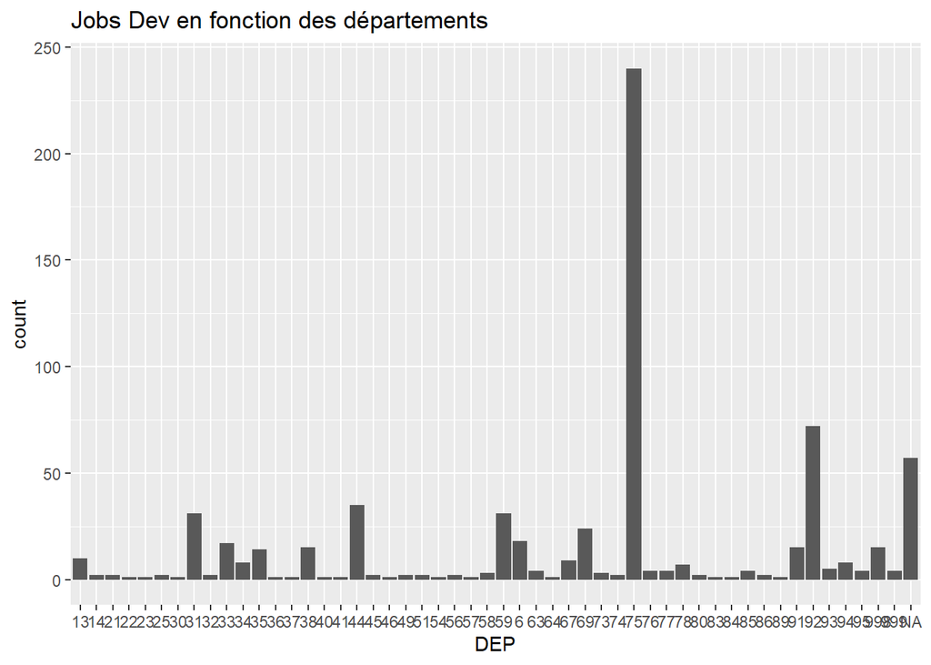

```r
ggplot(dataDev) + aes(x = DEP) + geom_bar() + ggtitle("Jobs Dev en fonction des départements")
```

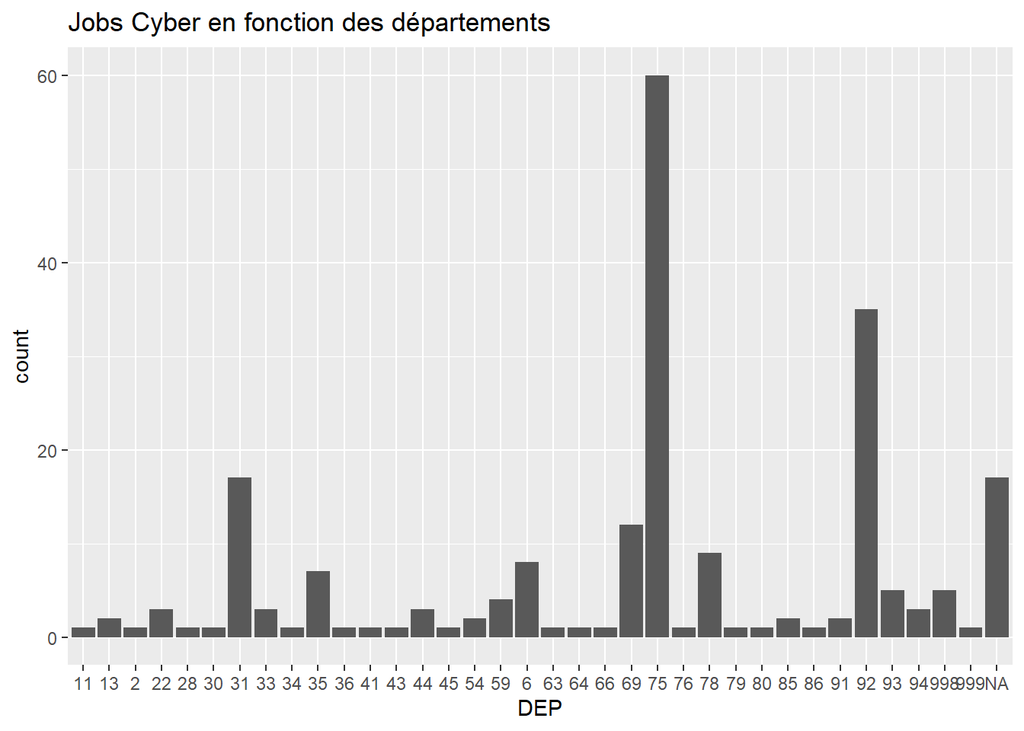

```r
ggplot(dataCyber) + aes(x = DEP) + geom_bar() + ggtitle("Jobs Cyber en fonction des départements")
```

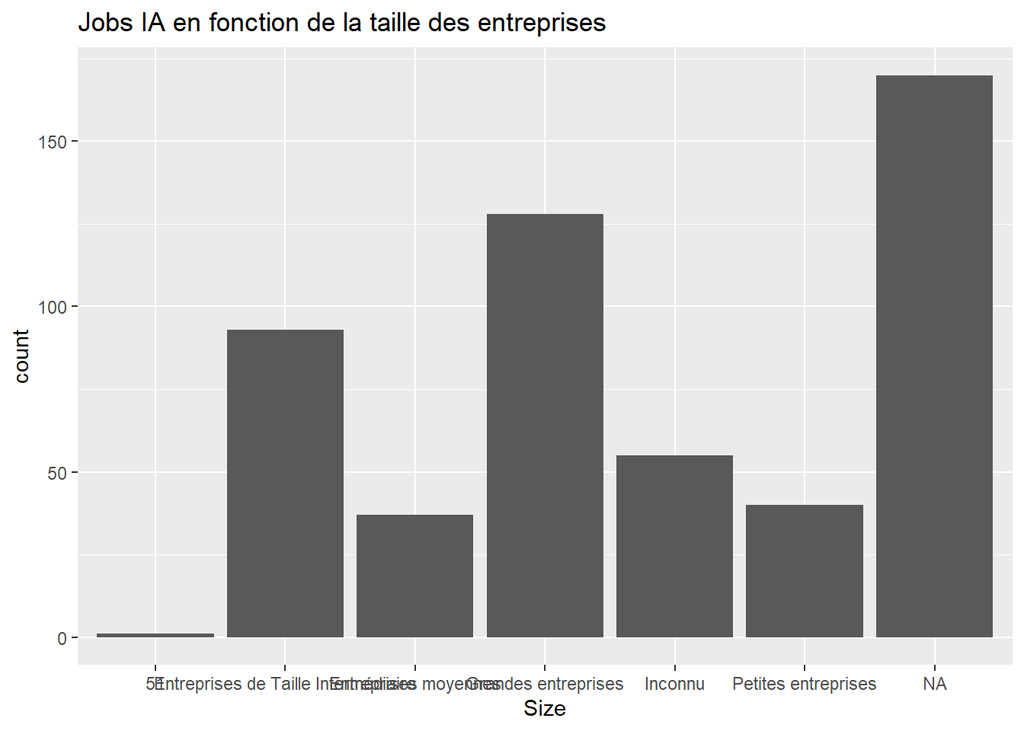

```r
ggplot(dataIA) + aes(x = Size) + geom_bar() + ggtitle("Jobs IA en fonction de la taille des entreprises")
```

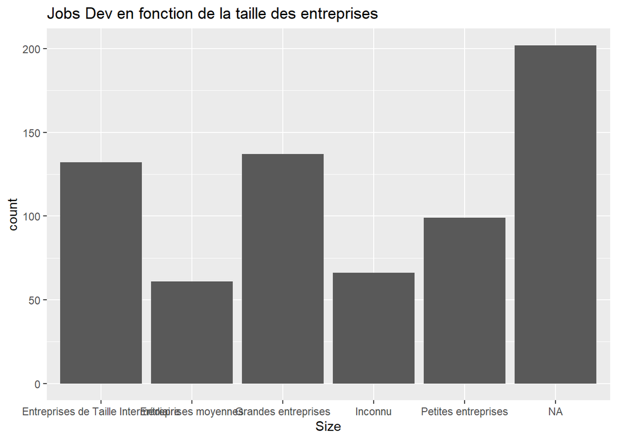

```r
ggplot(dataDev) + aes(x = Size) + geom_bar() + ggtitle("Jobs Dev en fonction de la taille des entreprises")
```

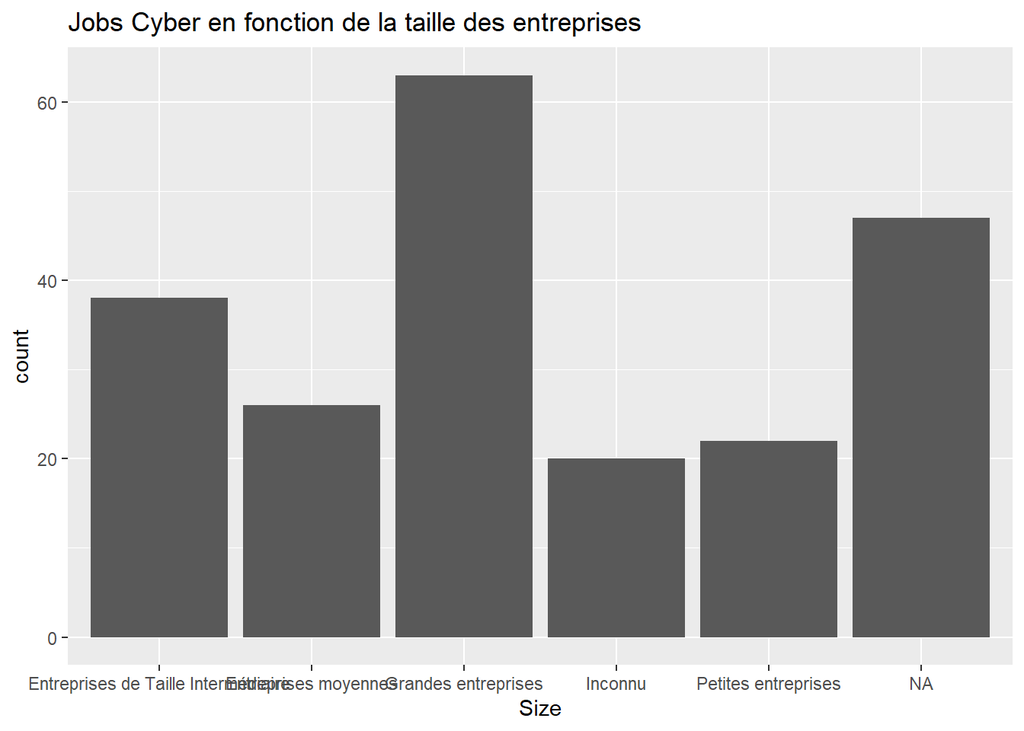

```r
ggplot(dataCyber) + aes(x = Size) + geom_bar() + ggtitle("Jobs Cyber en fonction de la taille des entreprises")
```

On peut noter avant toute chose qu’il y a beaucoup de jobs sans indication (NA). Les jobs IA sont concentrés principalement dans les grandes entreprises et les entreprises de taille intermédiaire. Les jobs Dev sont également concentrés dans les grandes entreprises et les entreprises de taille intermédiaire. Et les jobs Cyber sont concentrés dans les grandes entreprises.

# ESTIMATIONS

### Modèle MCO

```r
attach(data2)
Modele1=lm(Experience_min~Job+DEP+Companysector+Size)
coefficients(Modele1)
```

```
##                                            (Intercept)
##                                             2.88911392
##                                                 JobDev
##                                            -0.50299779
##                                                  JobIA
##                                            -0.69183207
##                                                  DEP14
##                                             2.67585719
##                                                  DEP21
##                                            -2.72705321
##                                                  DEP22
##                                             2.79023660
##                                                  DEP23
##                                            -3.32141476
##                                                  DEP28
##                                            -1.23298624
##                                                  DEP29
##                                            -2.85474452
##                                                  DEP30
##                                            -1.84632403
##                                                  DEP31
##                                            -0.58087421
##                                                  DEP33
##                                            -0.90957563
##                                                  DEP34
##                                            -0.18419224
##                                                  DEP35
##                                            -1.83982900
##                                                  DEP36
##                                            -2.21684936
##                                                  DEP37
##                                            -1.53732601
##                                                  DEP38
##                                            -0.47779976
##                                                  DEP40
##                                            -4.08106743
##                                                  DEP41
##                                            -1.90436806
##                                                  DEP43
##                                             1.13553169
```

[output cut: 87 more lines]

```
##                                             0.35467177
##                   CompanysectorTransport et logistique
##                                            -0.57843039
##                           CompanysectorVente au détail
##                                            -0.96429561
##                       CompanysectorVoyages et tourisme
##                                             0.77783596
##                               SizeEntreprises moyennes
##                                            -0.14941813
##                                SizeGrandes entreprises
##                                             0.65746267
##                                            SizeInconnu
##                                             1.05991016
##                                SizePetites entreprises
##                                             0.21616456
```

```r
anova(Modele1)
```

```
## Analysis of Variance Table
##
## Response: Experience_min
##                Df  Sum Sq Mean Sq F value    Pr(>F)
## Job             2   65.77  32.883  6.4804  0.001645 **
## DEP            45  475.08  10.557  2.0806 7.814e-05 ***
## Companysector  19   86.85   4.571  0.9009  0.582090
## Size            4   43.30  10.825  2.1333  0.075311 .
## Residuals     586 2973.47   5.074
## ---
## Signif. codes:  0 '***' 0.001 '**' 0.01 '*' 0.05 '.' 0.1 ' ' 1
```

On interprète maintenant les coefficients. Par exemple, pour DEP14, on obtient le modèle suivant : 2.67X + 2.88 Les variables DEP et Job sont significatives Le coefficient est positif donc la présence de la modalité augmente l’expérience minimale.

Evaluation de l’hypothèse de normalité des résidus Cette hypothèse peut s’évaluer graphiquement à l’aide d’un QQplot. Si les résidus sont bien distribués le long de la droite figurant sur le plot, alors l’hypothèse de normalité est acceptée. A l’inverse, s’ils s’en écartent, alors l’hypothèse de normalité est rejetée.

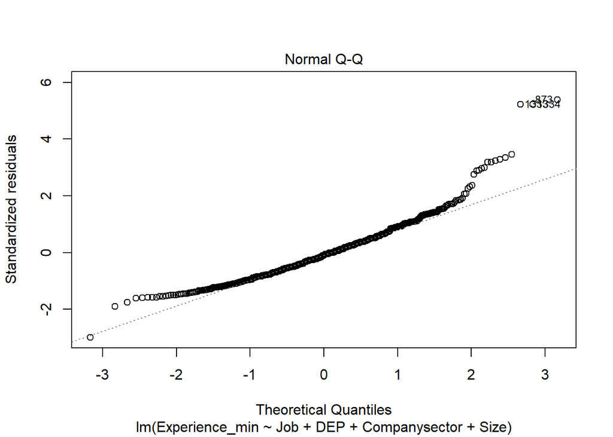

```r
plot(Modele1,2)
```

Ici, l’alignement des points sur la droite est discutable. Le test de Shapiro-Wilk peut également être employé pour évaluer la normalité des résidus. L’hypothèse de normalité est rejetée si la p-value est inférieure à 0.05.

```r
shapiro.test(residuals(Modele1))
```

```
##
##  Shapiro-Wilk normality test
##
## data:  residuals(Modele1)
## W = 0.92711, p-value < 2.2e-16
```

L’hypothèse de normalité est donc rejetée

Evaluation de l’hypothèse d’homogénéité des résidus On évalue cette hypothèse en employant le test de Breush-Pagan. L’hypothèse d’homogénéité est rejetée si la p-value est inférieure à 0.05

```r
ncvTest(Modele1)
```

```
## Non-constant Variance Score Test
## Variance formula: ~ fitted.values
## Chisquare = 69.9134, Df = 1, p = < 2.22e-16
```

Ici, le test rejette l’hypothèse d’homogénéité.

```r
summary(Modele1)
```

```
##
## Call:
## lm(formula = Experience_min ~ Job + DEP + Companysector + Size)
##
## Residuals:
##     Min      1Q  Median      3Q     Max
## -4.7485 -1.4908 -0.1361  1.1142 11.9686
##
## Coefficients:
##                                                        Estimate Std. Error
## (Intercept)                                             2.88911    0.87535
## JobDev                                                 -0.50300    0.27802
## JobIA                                                  -0.69183    0.28637
## DEP14                                                   2.67586    2.42783
## DEP21                                                  -2.72705    1.78931
## DEP22                                                   2.79024    1.40839
## DEP23                                                  -3.32141    2.73701
## DEP28                                                  -1.23299    2.55680
## DEP29                                                  -2.85474    2.40287
## DEP30                                                  -1.84632    1.80216
## DEP31                                                  -0.58087    0.83493
## DEP33                                                  -0.90958    1.28243
## DEP34                                                  -0.18419    1.78824
## DEP35                                                  -1.83983    0.96963
## DEP36                                                  -2.21685    1.51798
## DEP37                                                  -1.53733    1.77360
## DEP38                                                  -0.47780    0.89361
## DEP40                                                  -4.08107    2.55090
## DEP41                                                  -1.90437    1.55090
## DEP43                                                   1.13553    2.40623
## DEP44                                                  -1.01876    0.86079
## DEP45                                                   1.52859    1.78971
## DEP51                                                  -1.27519    2.44088
## DEP54                                                  -0.01389    2.38928
## DEP56                                                  -2.13073    2.39589
## DEP59                                                  -1.44643    0.87090
## DEP6                                                   -1.28255    0.86847
## DEP60                                                  -2.94151    2.54532
## DEP63                                                   0.42961    1.54411
## DEP64                                                  -1.51083    1.82171
```

[output cut: 105 more lines]

```
## CompanysectorTélécommunications                          0.527  0.59873
## CompanysectorTransport et logistique                    -0.488  0.62554
## CompanysectorVente au détail                            -0.939  0.34829
## CompanysectorVoyages et tourisme                         0.549  0.58348
## SizeEntreprises moyennes                                -0.353  0.72441
## SizeGrandes entreprises                                  2.567  0.01051 *
## SizeInconnu                                              0.860  0.38987
## SizePetites entreprises                                  0.695  0.48709
## ---
## Signif. codes:  0 '***' 0.001 '**' 0.01 '*' 0.05 '.' 0.1 ' ' 1
##
## Residual standard error: 2.253 on 586 degrees of freedom
##   (780 observations deleted due to missingness)
## Multiple R-squared:  0.1841, Adjusted R-squared:  0.08665
## F-statistic: 1.889 on 70 and 586 DF,  p-value: 4.69e-05
```

```r
summary(Modele1)$r.squared
```

```
## [1] 0.1841151
```

```r
summary(Modele1)$adj.r.squared
```

```
## [1] 0.08665444
```

```r
summary(Modele1)$sigma
```

```
## [1] 2.252594
```

Le R² tend à surévaluer la qualité de la régression linéaire. Sa valeur augmente toujours car le nombre d’effets est inclus dans le modèle. La mesure R² ajusté tente de corriger cette surévaluation.

Le R² vaut 0.18 et est très éloigné de 1 (modèle parfaitement ajusté). Le R² ajusté n’est pas bon non plus. et l’écart-type des résidus est éloigné de 0. On peut donc conclure que l’ajustement du modèle aux données n’est pas bon.

```r
dataNoStage = subset(data2, stage==1)
attach(dataNoStage)
Modele2=lm(Experience_min~Job+DEP+Companysector+Size)
coefficients(Modele2)
```

```
##                                            (Intercept)
##                                           -0.346849568
##                                                 JobDev
##                                            0.044946179
##                                                  JobIA
##                                            0.201496677
##                                                  DEP29
##                                            0.391145479
##                                                  DEP31
##                                            0.338584122
##                                                  DEP34
##                                           -0.661920984
##                                                  DEP38
##                                           -0.494334425
##                                                  DEP41
##                                            0.289107571
##                                                  DEP44
##                                            0.381008219
##                                                  DEP51
##                                            0.350438816
##                                                  DEP59
##                                            0.972891796
##                                                   DEP6
##                                            0.408883237
##                                                  DEP64
##                                            0.247508840
##                                                  DEP66
##                                            0.391145479
##                                                  DEP69
##                                            0.266959616
##                                                  DEP74
##                                            0.524150060
##                                                  DEP75
##                                            0.463742246
##                                                  DEP78
##                                            0.352807356
##                                                  DEP91
##                                            0.379823105
##                                                  DEP92
##                                            0.522433808
```

[output cut: 19 more lines]

```
##                                            0.143636639
##                  CompanysectorServices aux entreprises
##                                           -0.222246671
##                        CompanysectorTélécommunications
##                                            0.076858450
##                   CompanysectorTransport et logistique
##                                            0.169239179
##                           CompanysectorVente au détail
##                                            0.212819051
##                               SizeEntreprises moyennes
##                                            0.001716251
##                                SizeGrandes entreprises
##                                           -0.245792588
##                                SizePetites entreprises
##                                            1.029520545
```

```r
anova(Modele2)
```

```
## Analysis of Variance Table
##
## Response: Experience_min
##               Df  Sum Sq Mean Sq F value   Pr(>F)
## Job            2  0.1927 0.09636  0.3985 0.672960
## DEP           19  1.8098 0.09525  0.3939 0.986876
## Companysector 12  1.2152 0.10126  0.4188 0.950811
## Size           3  3.2702 1.09006  4.5078 0.006194 **
## Residuals     65 15.7181 0.24182
## ---
## Signif. codes:  0 '***' 0.001 '**' 0.01 '*' 0.05 '.' 0.1 ' ' 1
```

On interprète maintenant les coefficients. Par exemple, pour les Petites entreprises, on obtient le modèle suivant : 1.02X - 0.34 La variable Size est significative. Le coefficient est positif donc la présence de la modalité augmente l’expérience minimale.

```r
shapiro.test(residuals(Modele2)) #
```

```
##
##  Shapiro-Wilk normality test
##
## data:  residuals(Modele2)
## W = 0.58983, p-value = 1.933e-15
```

```r
ncvTest(Modele2) #
```

```
## Non-constant Variance Score Test
## Variance formula: ~ fitted.values
## Chisquare = 261.8983, Df = 1, p = < 2.22e-16
```

L’hypothèse de normalité est rejetée. Le test rejette l’hypothèse d’homogénéité.

```r
summary(Modele2)
```

```
##
## Call:
## lm(formula = Experience_min ~ Job + DEP + Companysector + Size)
##
## Residuals:
##      Min       1Q   Median       3Q      Max
## -1.16865 -0.12961 -0.00729  0.03834  2.22656
##
## Coefficients:
##                                                         Estimate Std. Error
## (Intercept)                                            -0.346850   0.752074
## JobDev                                                  0.044946   0.185193
## JobIA                                                   0.201497   0.182864
## DEP29                                                   0.391145   0.886095
## DEP31                                                   0.338584   0.742880
## DEP34                                                  -0.661921   1.041353
## DEP38                                                  -0.494334   0.806654
## DEP41                                                   0.289108   0.884250
## DEP44                                                   0.381008   0.927213
## DEP51                                                   0.350439   0.892320
## DEP59                                                   0.972892   0.768244
## DEP6                                                    0.408883   0.752919
## DEP64                                                   0.247509   0.843924
## DEP66                                                   0.391145   0.886095
## DEP69                                                   0.266960   0.888024
## DEP74                                                   0.524150   1.006690
## DEP75                                                   0.463742   0.741821
## DEP78                                                   0.352807   0.758499
## DEP91                                                   0.379823   0.729452
## DEP92                                                   0.522434   0.698810
## DEP94                                                   0.314287   0.868644
## DEP95                                                   0.601798   0.901142
## CompanysectorAssurance                                 -0.079105   0.363044
## CompanysectorConstruction, réparation et entretien      0.083954   0.544232
## CompanysectorFabrication                                0.191387   0.323710
## CompanysectorFinances                                   0.040707   0.260969
## CompanysectorGouvernement                               1.391145   0.886095
## CompanysectorInformatique                              -0.054102   0.228352
## CompanysectorMédias                                    -0.220530   0.576799
## CompanysectorPétrole, gaz, énergie et services publics  0.143637   0.232678
```

[output cut: 37 more lines]

```
## CompanysectorPétrole, gaz, énergie et services publics   0.617  0.53918
## CompanysectorServices aux entreprises                   -0.696  0.48897
## CompanysectorTélécommunications                          0.280  0.78041
## CompanysectorTransport et logistique                     0.288  0.77394
## CompanysectorVente au détail                             0.375  0.70852
## SizeEntreprises moyennes                                 0.004  0.99717
## SizeGrandes entreprises                                 -1.308  0.19545
## SizePetites entreprises                                  2.942  0.00452 **
## ---
## Signif. codes:  0 '***' 0.001 '**' 0.01 '*' 0.05 '.' 0.1 ' ' 1
##
## Residual standard error: 0.4917 on 65 degrees of freedom
##   (118 observations deleted due to missingness)
## Multiple R-squared:  0.2922, Adjusted R-squared:  -0.09986
## F-statistic: 0.7453 on 36 and 65 DF,  p-value: 0.8295
```

```r
summary(Modele2)$r.squared
```

```
## [1] 0.2921665
```

```r
summary(Modele2)$adj.r.squared
```

```
## [1] -0.09986433
```

```r
summary(Modele2)$sigma
```

```
## [1] 0.4917483
```

Le R² vaut : 0.2921665 Le R² ajusté vaut : -0.09986433 L’écart-type des résidus vaut : 0.4917483

Le R² vaut 0.29 et reste très éloigné de 1. Le R² ajusté permet de dire que ce modèle n’a pas de valeur prédictive car il est inférieur à 0. L’écart-type des résidus est cependant plus proche de 0. On peut donc conclure que l’ajustement du modèle aux données est meilleure qu’avant mais ne reste pas pas bon.

### REGRESSION LOGISTIQUE

Maintenant, nous allons faire une régression logistique :

```r
data3 <- mutate(data2, Indicatrice = ifelse(Experience_min <= 2, yes = "0", no = "1"))
data3$Indicatrice = as.numeric(data3$Indicatrice)
summary(data3)
```

```
##     Jobkey             Title               Job            JobExperience
##  Length:1437        Length:1437        Length:1437        Length:1437
##  Class :character   Class :character   Class :character   Class :character
##  Mode  :character   Mode  :character   Mode  :character   Mode  :character
##
##
##
##
##  Experience_min   Experience_max         stage          Company
##  Min.   : 0.000   Length:1437        Min.   :0.0000   Length:1437
##  1st Qu.: 0.000   Class :character   1st Qu.:0.0000   Class :character
##  Median : 2.000   Mode  :character   Median :0.0000   Mode  :character
##  Mean   : 2.023                      Mean   :0.1531
##  3rd Qu.: 3.000                      3rd Qu.:0.0000
##  Max.   :15.000                      Max.   :1.0000
##  NA's   :6
##    Location         Headquarters       Companysector      Yearfounded
##  Length:1437        Length:1437        Length:1437        Length:1437
##  Class :character   Class :character   Class :character   Class :character
##  Mode  :character   Mode  :character   Mode  :character   Mode  :character
##
##
##
##
##    Industry           Revenue              Size           Companytype
##  Length:1437        Length:1437        Length:1437        Length:1437
##  Class :character   Class :character   Class :character   Class :character
##  Mode  :character   Mode  :character   Mode  :character   Mode  :character
##
##
##
##
##      DEP                 REG         commune_homonyme   Indicatrice
##  Length:1437        Min.   : 11.00   Min.   :0.00000   Min.   :0.0000
##  Class :character   1st Qu.: 11.00   1st Qu.:0.00000   1st Qu.:0.0000
##  Mode  :character   Median : 11.00   Median :0.00000   Median :0.0000
##                     Mean   : 63.25   Mean   :0.07373   Mean   :0.4186
##                     3rd Qu.: 75.00   3rd Qu.:0.00000   3rd Qu.:1.0000
##                     Max.   :999.00   Max.   :1.00000   Max.   :1.0000
##                     NA's   :123      NA's   :162       NA's   :6
```

```r
data4 = na.omit(data3) #exclusion de tous les NA pour éviter l'erreur "Error in weights * y : argument non numérique pour un opérateur binaire"
summary(data4)
```

```
##     Jobkey             Title               Job            JobExperience
##  Length:587         Length:587         Length:587         Length:587
##  Class :character   Class :character   Class :character   Class :character
##  Mode  :character   Mode  :character   Mode  :character   Mode  :character
##
##
##
##  Experience_min   Experience_max         stage          Company
##  Min.   : 0.000   Length:587         Min.   :0.0000   Length:587
##  1st Qu.: 0.000   Class :character   1st Qu.:0.0000   Class :character
##  Median : 2.000   Mode  :character   Median :0.0000   Mode  :character
##  Mean   : 2.255                      Mean   :0.1635
##  3rd Qu.: 3.000                      3rd Qu.:0.0000
##  Max.   :15.000                      Max.   :1.0000
##    Location         Headquarters       Companysector      Yearfounded
##  Length:587         Length:587         Length:587         Length:587
##  Class :character   Class :character   Class :character   Class :character
##  Mode  :character   Mode  :character   Mode  :character   Mode  :character
##
##
##
##    Industry           Revenue              Size           Companytype
##  Length:587         Length:587         Length:587         Length:587
##  Class :character   Class :character   Class :character   Class :character
##  Mode  :character   Mode  :character   Mode  :character   Mode  :character
##
##
##
##      DEP                 REG        commune_homonyme   Indicatrice
##  Length:587         Min.   :11.00   Min.   :0.00000   Min.   :0.0000
##  Class :character   1st Qu.:11.00   1st Qu.:0.00000   1st Qu.:0.0000
##  Mode  :character   Median :11.00   Median :0.00000   Median :0.0000
##                     Mean   :34.66   Mean   :0.06644   Mean   :0.4583
##                     3rd Qu.:64.00   3rd Qu.:0.00000   3rd Qu.:1.0000
##                     Max.   :93.00   Max.   :1.00000   Max.   :1.0000
```

```r
attach(data4)
logit=glm(Indicatrice~Job+DEP+Companysector+Size, family=binomial(link="logit"))
summary(logit)
```

```
##
## Call:
## glm(formula = Indicatrice ~ Job + DEP + Companysector + Size,
##     family = binomial(link = "logit"))
##
## Deviance Residuals:
##     Min       1Q   Median       3Q      Max
## -1.6245  -0.9946  -0.4853   1.0353   2.2208
##
## Coefficients:
##                                                          Estimate Std. Error
## (Intercept)                                               0.20182    0.87144
## JobDev                                                   -0.08729    0.27721
## JobIA                                                    -0.38471    0.28680
## DEP21                                                   -17.12114 1696.73454
## DEP22                                                    15.74592 1385.37810
## DEP23                                                   -16.91757 2399.54520
## DEP28                                                   -15.81080 2399.54505
## DEP29                                                   -16.85693 2399.54486
## DEP30                                                   -16.39906 1679.38366
## DEP31                                                    -0.06731    0.81618
## DEP33                                                    -1.24627    1.39472
## DEP35                                                    -1.81018    1.07809
## DEP36                                                   -16.10086 1651.08829
## DEP37                                                    16.35415 2399.54485
## DEP38                                                    -0.17752    0.88523
## DEP40                                                   -17.74033 2399.54502
## DEP41                                                    -0.95736    1.51288
## DEP43                                                    16.64978 2399.54487
## DEP44                                                    -0.94753    0.85766
## DEP45                                                    -0.55298    1.63199
## DEP51                                                   -15.36901 2399.54491
## DEP54                                                    16.50115 2399.54485
## DEP56                                                   -16.04036 2399.54486
## DEP59                                                    -1.11521    0.86424
## DEP6                                                     -0.63631    0.84936
## DEP60                                                   -17.32489 2399.54504
## DEP63                                                     0.19154    1.44475
## DEP64                                                   -15.61639 2399.54487
## DEP66                                                    -0.44374    1.61636
```

[output cut: 93 more lines]

```
## CompanysectorVoyages et tourisme                        -0.172   0.8634
## SizeEntreprises moyennes                                -0.345   0.7299
## SizeGrandes entreprises                                  1.865   0.0622 .
## SizeInconnu                                              0.099   0.9213
## SizePetites entreprises                                  1.718   0.0857 .
## ---
## Signif. codes:  0 '***' 0.001 '**' 0.01 '*' 0.05 '.' 0.1 ' ' 1
##
## (Dispersion parameter for binomial family taken to be 1)
##
##     Null deviance: 809.66  on 586  degrees of freedom
## Residual deviance: 695.98  on 524  degrees of freedom
## AIC: 821.98
##
## Number of Fisher Scoring iterations: 15
```

```r
coef(logit)
```

```
##                                            (Intercept)
##                                             0.20181534
##                                                 JobDev
##                                            -0.08729308
##                                                  JobIA
##                                            -0.38471280
##                                                  DEP21
##                                           -17.12114315
##                                                  DEP22
##                                            15.74591838
##                                                  DEP23
##                                           -16.91756800
##                                                  DEP28
##                                           -15.81080476
##                                                  DEP29
##                                           -16.85692760
##                                                  DEP30
##                                           -16.39906202
##                                                  DEP31
##                                            -0.06731135
##                                                  DEP33
##                                            -1.24626520
##                                                  DEP35
##                                            -1.81017701
##                                                  DEP36
##                                           -16.10086047
##                                                  DEP37
##                                            16.35415155
##                                                  DEP38
##                                            -0.17751892
##                                                  DEP40
##                                           -17.74033393
##                                                  DEP41
##                                            -0.95735890
##                                                  DEP43
##                                            16.64977706
##                                                  DEP44
##                                            -0.94752857
##                                                  DEP45
##                                            -0.55298313
```

[output cut: 71 more lines]

```
##                                             0.14457806
##                   CompanysectorTransport et logistique
##                                            -0.38585287
##                           CompanysectorVente au détail
##                                            -0.57236620
##                       CompanysectorVoyages et tourisme
##                                            -0.23677932
##                               SizeEntreprises moyennes
##                                            -0.14862922
##                                SizeGrandes entreprises
##                                             0.47375664
##                                            SizeInconnu
##                                             0.15393956
##                                SizePetites entreprises
##                                             0.57744722
```

```r
logitprediction <- predict(logit, type = "response")
head(logitprediction)
```

```
##         1         2         3         4         5         6
## 0.5556554 0.6667102 0.5977079 0.2194905 0.3696978 0.5067500
```

```r
table(logitprediction > 0.5, Indicatrice)
```

```
##        Indicatrice
##           0   1
##   FALSE 217 105
##   TRUE  101 164
```

Nous avons donc 206 (105+101) prédictions incorrectes sur un total de 587, soit un taux de mauvais classement de 35,1 %.

### Identifions les variables ayant un effet significatif

Pour tester l’effet global sur un modèle, on a recours à la fonction drop1. Cette dernière va tour à tour supprimer chaque variable du modèle et réaliser une analyse de variance (ANOVA) pour voir si la variance change significativement.

```r
drop1(logit, test = "Chisq")
```

```
## Single term deletions
##
## Model:
## Indicatrice ~ Job + DEP + Companysector + Size
##               Df Deviance    AIC    LRT Pr(>Chi)
## <none>             695.98 821.98
## Job            2   698.44 820.44  2.455 0.292978
## DEP           38   765.51 815.51 69.526 0.001351 **
## Companysector 18   719.53 809.53 23.549 0.170367
## Size           4   702.12 820.12  6.138 0.189095
## ---
## Signif. codes:  0 '***' 0.001 '**' 0.01 '*' 0.05 '.' 0.1 ' ' 1
```

```r
anova(logit)
```

```
## Analysis of Deviance Table
##
## Model: binomial, link: logit
##
## Response: Indicatrice
##
## Terms added sequentially (first to last)
##
##
##               Df Deviance Resid. Df Resid. Dev
## NULL                            586     809.66
## Job            2    8.351       584     801.31
## DEP           38   77.324       546     723.98
## Companysector 18   21.864       528     702.12
## Size           4    6.138       524     695.98
```

Ainsi, dans le cas présent, la suppression de la variables Job ne modifie significativement pas le modèle, indiquant l’absence d’effet de cette variable.

### Sélection de modèles

On réalise un premier modèle avec toutes les variables spécifiées, puis on regarde s’il est possible d’améliorer le modèle en supprimant une des variables du modèle. Si plusieurs variables permettent d’améliorer le modèle, on supprimera la variable dont la suppression améliorera le plus le modèle. Puis on recommence le même procédé pour voir si la suppression d’une seconde variable peut encore améliorer le modèle et ainsi de suite. Lorsque le modèle ne peut plus être améliorer par la suppresion d’une variable, on s’arrête.

Il faut également définir un critère pour déterminer la qualité d’un modèle. Plus l’AIC sera faible, meilleur sera le modèle. La fonction step permet justement de sélectionner le meilleur modèle par une procédure pas à pas descendante basée sur la minimisation de l’AIC. La fonction affiche à l’écran les différentes étapes de la sélection et renvoie le modèle final.

```r
reg <- step(logit)
```

```
## Start:  AIC=821.98
## Indicatrice ~ Job + DEP + Companysector + Size
##
##                 Df Deviance    AIC
## - Companysector 18   719.53 809.53
## - DEP           38   765.51 815.51
## - Size           4   702.12 820.12
## - Job            2   698.44 820.44
## <none>               695.98 821.98
##
## Step:  AIC=809.53
## Indicatrice ~ Job + DEP + Size
##
##        Df Deviance    AIC
## - Size  4   723.98 805.98
## - DEP  38   795.00 809.00
## <none>      719.53 809.53
## - Job   2   725.06 811.06
##
## Step:  AIC=805.98
## Indicatrice ~ Job + DEP
##
##        Df Deviance    AIC
## <none>      723.98 805.98
## - DEP  38   801.31 807.31
## - Job   2   729.51 807.51
```

Le modèle initial a un AIC de 821.98. À la première étape, il apparait que la suppression de la variable Companysector permet de diminuer l’AIC à 809.53. Lors de la seconde étape, la suppression de la variable Size permet de diminuer l’AIC à 805.98. Lors de la troisième étape, toute suppression d’une autre variable ferait augmenter l’AIC. La procédure s’arrête donc.

```r
summary(reg)
```

```
##
## Call:
## glm(formula = Indicatrice ~ Job + DEP, family = binomial(link = "logit"))
##
## Deviance Residuals:
##    Min      1Q  Median      3Q     Max
## -1.627  -1.082  -0.614   1.043   1.877
##
## Coefficients:
##               Estimate Std. Error z value Pr(>|z|)
## (Intercept)    0.11865    0.71133   0.167   0.8675
## JobDev         0.02282    0.25549   0.089   0.9288
## JobIA         -0.44432    0.26785  -1.659   0.0971 .
## DEP21        -16.70755 1696.73449  -0.010   0.9921
## DEP22         16.44742 1385.37797   0.012   0.9905
## DEP23        -16.70755 2399.54482  -0.007   0.9944
## DEP28        -16.24040 2399.54481  -0.007   0.9946
## DEP29        -16.24040 2399.54481  -0.007   0.9946
## DEP30        -16.46801 1680.66808  -0.010   0.9922
## DEP31          0.24830    0.74649   0.333   0.7394
## DEP33         -1.02017    1.34466  -0.759   0.4480
## DEP35         -1.71440    1.02940  -1.665   0.0958 .
## DEP36        -16.69616 1696.69735  -0.010   0.9921
## DEP37         16.89174 2399.54481   0.007   0.9944
## DEP38         -0.25554    0.83977  -0.304   0.7609
## DEP40        -16.70755 2399.54482  -0.007   0.9944
## DEP41         -0.67939    1.40646  -0.483   0.6291
## DEP43         16.44742 2399.54482   0.007   0.9945
## DEP44         -0.91525    0.79124  -1.157   0.2474
## DEP45         -0.13007    1.57451  -0.083   0.9342
## DEP51        -16.24040 2399.54481  -0.007   0.9946
## DEP54         16.44742 2399.54482   0.007   0.9945
## DEP56          0.71505    1.40748   0.508   0.6114
## DEP59         -0.90104    0.80122  -1.125   0.2608
## DEP6          -0.50607    0.78277  -0.647   0.5180
## DEP60        -16.24040 2399.54481  -0.007   0.9946
## DEP63         -0.02548    1.21643  -0.021   0.9833
## DEP64        -16.24040 2399.54481  -0.007   0.9946
## DEP66          0.10351    1.57732   0.066   0.9477
## DEP67          0.87159    0.98006   0.889   0.3738
## DEP69          0.18404    0.77148   0.239   0.8115
## DEP73        -16.70755 2399.54482  -0.007   0.9944
## DEP75          0.46515    0.69588   0.668   0.5039
## DEP78         -0.77167    0.91114  -0.847   0.3970
## DEP82        -16.24040 2399.54481  -0.007   0.9946
## DEP86         16.42459 1696.73449   0.010   0.9923
## DEP91         -1.18833    0.78234  -1.519   0.1288
## DEP92         -0.34711    0.71931  -0.483   0.6294
## DEP93         -0.12626    1.07288  -0.118   0.9063
## DEP94         -0.68473    0.98443  -0.696   0.4867
## DEP95         -0.53085    1.40476  -0.378   0.7055
## ---
## Signif. codes:  0 '***' 0.001 '**' 0.01 '*' 0.05 '.' 0.1 ' ' 1
##
## (Dispersion parameter for binomial family taken to be 1)
##
##     Null deviance: 809.66  on 586  degrees of freedom
## Residual deviance: 723.98  on 546  degrees of freedom
## AIC: 805.98
##
## Number of Fisher Scoring iterations: 15
```

On interprète maintenant les coefficients. Par exemple, pour les JobsIA, on obtient le modèle suivant : -0.44X + 0.11 Le coefficient est négatif donc un jobIA diminue le logit de 0.44. Si le logit diminue la probabilité diminue. Un job IA veut dire que la probabilité de Y=1 est faible. Ici, un job IA veut dire que la probabilité qu’une offre d’emploi soit une offre “Sénior” est faible.

```r
dataNoStage2 = subset(data4, stage==1)
attach(dataNoStage2)
logit2=glm(Indicatrice~Job+DEP+Companysector+Size, family=binomial(link="logit"))
summary(logit2)
```

```
##
## Call:
## glm(formula = Indicatrice ~ Job + DEP + Companysector + Size,
##     family = binomial(link = "logit"))
##
## Deviance Residuals:
##        Min          1Q      Median          3Q         Max
## -1.062e-05  -3.094e-06  -2.213e-06  -2.110e-08   1.570e-05
##
## Coefficients:
##                                                          Estimate Std. Error
## (Intercept)                                            -6.892e+01  5.909e+05
## JobDev                                                 -2.261e+00  2.366e+05
## JobIA                                                   2.084e+00  1.574e+05
## DEP29                                                   8.309e+01  8.133e+05
## DEP31                                                  -8.371e+00  7.185e+05
## DEP38                                                   4.407e+01  6.635e+05
## DEP41                                                   4.407e+01  6.635e+05
## DEP44                                                   6.313e+00  7.965e+05
## DEP51                                                   8.341e+01  8.096e+05
## DEP59                                                   9.064e+01  6.001e+05
## DEP6                                                    4.426e+01  5.914e+05
## DEP64                                                   4.511e+01  6.117e+05
## DEP66                                                   8.309e+01  8.133e+05
## DEP69                                                   4.842e+01  6.862e+05
## DEP75                                                   4.317e+01  6.050e+05
## DEP78                                                   4.323e+01  6.072e+05
## DEP91                                                   4.615e+01  5.073e+05
## DEP92                                                   4.529e+01  5.234e+05
## DEP94                                                   4.349e+01  6.474e+05
## DEP95                                                   8.842e+01  7.027e+05
## CompanysectorAssurance                                  3.830e+01  4.521e+05
## CompanysectorConstruction, réparation et entretien      4.426e+01  3.723e+05
## CompanysectorFabrication                                3.902e+01  4.332e+05
## CompanysectorFinances                                  -3.235e-01  1.269e+05
## CompanysectorGouvernement                               8.309e+01  8.133e+05
## CompanysectorInformatique                              -9.868e-01  1.468e+05
## CompanysectorMédias                                    -6.730e-01  4.490e+05
## CompanysectorPétrole, gaz, énergie et services publics  3.798e+01  4.472e+05
## CompanysectorServices aux entreprises                  -2.963e+00  2.223e+05
```

[output cut: 35 more lines]

```
## CompanysectorServices aux entreprises                        0        1
## CompanysectorTélécommunications                              0        1
## CompanysectorTransport et logistique                         0        1
## CompanysectorVente au détail                                 0        1
## SizeEntreprises moyennes                                     0        1
## SizeGrandes entreprises                                      0        1
## SizePetites entreprises                                      0        1
##
## (Dispersion parameter for binomial family taken to be 1)
##
##     Null deviance: 1.9443e+01  on 95  degrees of freedom
## Residual deviance: 1.4759e-09  on 61  degrees of freedom
## AIC: 70
##
## Number of Fisher Scoring iterations: 25
```

```r
coef(logit2)
```

```
##                                            (Intercept)
##                                            -68.9192535
##                                                 JobDev
##                                             -2.2606700
##                                                  JobIA
##                                              2.0843393
##                                                  DEP29
##                                             83.0863103
##                                                  DEP31
##                                             -8.3705822
##                                                  DEP38
##                                             44.0702022
##                                                  DEP41
##                                             44.0702022
##                                                  DEP44
##                                              6.3134285
##                                                  DEP51
##                                             83.4098451
##                                                  DEP59
##                                             90.6388840
##                                                   DEP6
##                                             44.2633820
##                                                  DEP64
##                                             45.1072410
##                                                  DEP66
##                                             83.0863103
##                                                  DEP69
##                                             48.4152116
##                                                  DEP75
##                                             43.1715574
##                                                  DEP78
##                                             43.2311880
##                                                  DEP91
##                                             46.1463064
##                                                  DEP92
##                                             45.2868656
##                                                  DEP94
##                                             43.4882627
##                                                  DEP95
##                                             88.4181374
```

[output cut: 15 more lines]

```
##                                             37.9790693
##                  CompanysectorServices aux entreprises
##                                             -2.9627869
##                        CompanysectorTélécommunications
##                                             39.5980476
##                   CompanysectorTransport et logistique
##                                             43.3611174
##                           CompanysectorVente au détail
##                                             39.0243433
##                               SizeEntreprises moyennes
##                                              2.2897764
##                                SizeGrandes entreprises
##                                            -42.8174646
##                                SizePetites entreprises
##                                             52.5937489
```

```r
logitprediction2 <- predict(logit2, type = "response")
head(logitprediction2)
```

```
##            1            2            3            4            5            6
## 1.180937e-12 2.220446e-16 2.220446e-16 2.731572e-12 2.220446e-16 2.220446e-16
```

```r
table(logitprediction2 > 0.5, Indicatrice)
```

```
##        Indicatrice
##          0  1
##   FALSE 94  0
##   TRUE   0  2
```

Nous avons donc 0 prédiction incorrecte sur un total de 96, soit un taux de mauvais classement de 0 %.

```r
drop1(logit2, test = "Chisq")
```

```
## Single term deletions
##
## Model:
## Indicatrice ~ Job + DEP + Companysector + Size
##               Df Deviance    AIC    LRT Pr(>Chi)
## <none>             0.0000 70.000
## Job            2   0.0000 66.000 0.0000  1.00000
## DEP           17   8.7541 44.754 8.7541  0.94766
## Companysector 12   0.0000 46.000 0.0000  1.00000
## Size           3   9.8254 73.825 9.8254  0.02011 *
## ---
## Signif. codes:  0 '***' 0.001 '**' 0.01 '*' 0.05 '.' 0.1 ' ' 1
```

```r
anova(logit2)
```

```
## Analysis of Deviance Table
##
## Model: binomial, link: logit
##
## Response: Indicatrice
##
## Terms added sequentially (first to last)
##
##
##               Df Deviance Resid. Df Resid. Dev
## NULL                             95    19.4428
## Job            2   0.7256        93    18.7172
## DEP           17   5.8289        76    12.8884
## Companysector 12   3.0630        64     9.8254
## Size           3   9.8254        61     0.0000
```

```r
reg2 <- step(logit2)
```

```
## Start:  AIC=70
## Indicatrice ~ Job + DEP + Companysector + Size
##
##                 Df Deviance    AIC
## - DEP           17   8.7541 44.754
## - Companysector 12   0.0000 46.000
## - Job            2   0.0000 66.000
## <none>               0.0000 70.000
## - Size           3   9.8254 73.825
##
## Step:  AIC=44.75
## Indicatrice ~ Job + Companysector + Size
##
##                 Df Deviance    AIC
## - Companysector 12  10.1174 22.117
## - Job            2   9.6567 41.657
## - Size           3  13.7525 43.752
## <none>               8.7541 44.754
##
## Step:  AIC=22.12
## Indicatrice ~ Job + Size
##
##        Df Deviance    AIC
## - Job   2   10.713 18.713
## <none>      10.117 22.117
## - Size  3   18.717 24.717
##
## Step:  AIC=18.71
## Indicatrice ~ Size
##
##        Df Deviance    AIC
## <none>      10.713 18.713
## - Size  3   19.443 21.443
```

Le modèle initial a un AIC de 70. À la première étape, il apparait que la suppression de la variable DEP permet de diminuer l’AIC à 44.75. Lors de la seconde étape, la suppression de la variable CompanySector permet de diminuer l’AIC à 22.12. Lors de la troisième étape, il apparait que la suppression de la variable Job permet de diminuer l’AIC à 18.71. Lors de la quatrième étape, toute suppression d’une autre variable ferait augmenter l’AIC. La procédure s’arrête donc.

```r
anova(logit2, reg2, test = "Chisq")
```

```
## Analysis of Deviance Table
##
## Model 1: Indicatrice ~ Job + DEP + Companysector + Size
## Model 2: Indicatrice ~ Size
##   Resid. Df Resid. Dev  Df Deviance Pr(>Chi)
## 1        61      0.000
## 2        92     10.713 -31  -10.713   0.9997
```

Il n’y a pas de différences significatives entre nos deux modèles. Autrement dit, notre second modèle explique tout autant de variance que notre premier modèle, tout en étant plus parcimonieux.

```r
summary(reg2)
```

```
##
## Call:
## glm(formula = Indicatrice ~ Size, family = binomial(link = "logit"))
##
## Deviance Residuals:
##      Min        1Q    Median        3Q       Max
## -1.17741  -0.00002  -0.00002  -0.00002   2.44775
##
## Coefficients:
##                           Estimate Std. Error z value Pr(>|z|)
## (Intercept)                 -2.944      1.026  -2.870  0.00411 **
## SizeEntreprises moyennes   -19.622  27826.056  -0.001  0.99944
## SizeGrandes entreprises    -19.622   5719.830  -0.003  0.99726
## SizePetites entreprises      2.944      1.747   1.685  0.09194 .
## ---
## Signif. codes:  0 '***' 0.001 '**' 0.01 '*' 0.05 '.' 0.1 ' ' 1
##
## (Dispersion parameter for binomial family taken to be 1)
##
##     Null deviance: 19.443  on 95  degrees of freedom
## Residual deviance: 10.713  on 92  degrees of freedom
## AIC: 18.713
##
## Number of Fisher Scoring iterations: 21
```

On peut maintenant interpréter les résultats avec le modèle qu’on a retenu. Par exemple, pour les entreprise moyennes, on a le modèle suivant : -19.622X - 2.94. Le coefficient est négatif donc quand la taille de l’entreprise est moyenne, le logit diminue de 19. Ici, quand la taille de l’entreprise est moyenne cela veut dire que la probabilité qu’une offre d’emploi soit une offre “Sénior” est faible.